# chapter5

Rumo Schilling

2023-02-02

## R Markdown

```r
library(nycflights13)
library(tidyverse)
#arrival delay 2 or more hrs
flights %>%
  filter(arr_delay >=2)
```

```
## # A tibble: 127,929 × 19
##     year month   day dep_time sched_de…¹ dep_d…² arr_t…³ sched…⁴ arr_d…⁵ carrier
##    <int> <int> <int>    <int>      <int>   <dbl>   <int>   <int>   <dbl> <chr>
##  1  2013     1     1      517        515       2     830     819      11 UA
##  2  2013     1     1      533        529       4     850     830      20 UA
##  3  2013     1     1      542        540       2     923     850      33 AA
##  4  2013     1     1      554        558      -4     740     728      12 UA
##  5  2013     1     1      555        600      -5     913     854      19 B6
##  6  2013     1     1      558        600      -2     753     745       8 AA
##  7  2013     1     1      558        600      -2     924     917       7 UA
##  8  2013     1     1      559        600      -1     941     910      31 AA
##  9  2013     1     1      600        600       0     837     825      12 MQ
## 10  2013     1     1      602        605      -3     821     805      16 MQ
## # … with 127,919 more rows, 9 more variables: flight <int>, tailnum <chr>,
## #   origin <chr>, dest <chr>, air_time <dbl>, distance <dbl>, hour <dbl>,
## #   minute <dbl>, time_hour <dttm>, and abbreviated variable names
## #   ¹sched_dep_time, ²dep_delay, ³arr_time, ⁴sched_arr_time, ⁵arr_delay
```

```r
"arrives in Houston"
```

```
## [1] "arrives in Houston"
```

```r
flights %>%
  filter(dest == "HOU" | dest =="IAH")
```

```
## # A tibble: 9,313 × 19
##     year month   day dep_time sched_de…¹ dep_d…² arr_t…³ sched…⁴ arr_d…⁵ carrier
##    <int> <int> <int>    <int>      <int>   <dbl>   <int>   <int>   <dbl> <chr>
##  1  2013     1     1      517        515       2     830     819      11 UA
##  2  2013     1     1      533        529       4     850     830      20 UA
##  3  2013     1     1      623        627      -4     933     932       1 UA
##  4  2013     1     1      728        732      -4    1041    1038       3 UA
##  5  2013     1     1      739        739       0    1104    1038      26 UA
##  6  2013     1     1      908        908       0    1228    1219       9 UA
##  7  2013     1     1     1028       1026       2    1350    1339      11 UA
##  8  2013     1     1     1044       1045      -1    1352    1351       1 UA
##  9  2013     1     1     1114        900     134    1447    1222     145 UA
## 10  2013     1     1     1205       1200       5    1503    1505      -2 UA
## # … with 9,303 more rows, 9 more variables: flight <int>, tailnum <chr>,
## #   origin <chr>, dest <chr>, air_time <dbl>, distance <dbl>, hour <dbl>,
## #   minute <dbl>, time_hour <dttm>, and abbreviated variable names
## #   ¹sched_dep_time, ²dep_delay, ³arr_time, ⁴sched_arr_time, ⁵arr_delay
```

```r
"from Delta,United or American"
```

```
## [1] "from Delta,United or American"
```

```r
flights %>%
  filter(carrier == "AA" |carrier == "UA" | carrier == "DL")
```

```
## # A tibble: 139,504 × 19
##     year month   day dep_time sched_de…¹ dep_d…² arr_t…³ sched…⁴ arr_d…⁵ carrier
##    <int> <int> <int>    <int>      <int>   <dbl>   <int>   <int>   <dbl> <chr>
##  1  2013     1     1      517        515       2     830     819      11 UA
##  2  2013     1     1      533        529       4     850     830      20 UA
##  3  2013     1     1      542        540       2     923     850      33 AA
##  4  2013     1     1      554        600      -6     812     837     -25 DL
##  5  2013     1     1      554        558      -4     740     728      12 UA
##  6  2013     1     1      558        600      -2     753     745       8 AA
##  7  2013     1     1      558        600      -2     924     917       7 UA
##  8  2013     1     1      558        600      -2     923     937     -14 UA
##  9  2013     1     1      559        600      -1     941     910      31 AA
## 10  2013     1     1      559        600      -1     854     902      -8 UA
## # … with 139,494 more rows, 9 more variables: flight <int>, tailnum <chr>,
## #   origin <chr>, dest <chr>, air_time <dbl>, distance <dbl>, hour <dbl>,
## #   minute <dbl>, time_hour <dttm>, and abbreviated variable names
## #   ¹sched_dep_time, ²dep_delay, ³arr_time, ⁴sched_arr_time, ⁵arr_delay
```

```r
"Flew in the Summer"
```

```
## [1] "Flew in the Summer"
```

```r
flights %>%
  filter(month == "Juni" | month == "July" | month == "August")
```

```
## # A tibble: 0 × 19
## # … with 19 variables: year <int>, month <int>, day <int>, dep_time <int>,
## #   sched_dep_time <int>, dep_delay <dbl>, arr_time <int>,
## #   sched_arr_time <int>, arr_delay <dbl>, carrier <chr>, flight <int>,
## #   tailnum <chr>, origin <chr>, dest <chr>, air_time <dbl>, distance <dbl>,
## #   hour <dbl>, minute <dbl>, time_hour <dttm>
```

```r
"Arrived 2+ hrs late but did not depart late"
```

```
## [1] "Arrived 2+ hrs late but did not depart late"
```

```r
flights %>%
  filter(arr_delay >=2 & dep_delay <= 0)
```

```
## # A tibble: 37,527 × 19
##     year month   day dep_time sched_de…¹ dep_d…² arr_t…³ sched…⁴ arr_d…⁵ carrier
##    <int> <int> <int>    <int>      <int>   <dbl>   <int>   <int>   <dbl> <chr>
##  1  2013     1     1      554        558      -4     740     728      12 UA
##  2  2013     1     1      555        600      -5     913     854      19 B6
##  3  2013     1     1      558        600      -2     753     745       8 AA
##  4  2013     1     1      558        600      -2     924     917       7 UA
##  5  2013     1     1      559        600      -1     941     910      31 AA
##  6  2013     1     1      600        600       0     837     825      12 MQ
##  7  2013     1     1      602        605      -3     821     805      16 MQ
##  8  2013     1     1      622        630      -8    1017    1014       3 US
##  9  2013     1     1      624        630      -6     909     840      29 EV
## 10  2013     1     1      624        630      -6     840     830      10 MQ
## # … with 37,517 more rows, 9 more variables: flight <int>, tailnum <chr>,
## #   origin <chr>, dest <chr>, air_time <dbl>, distance <dbl>, hour <dbl>,
## #   minute <dbl>, time_hour <dttm>, and abbreviated variable names
## #   ¹sched_dep_time, ²dep_delay, ³arr_time, ⁴sched_arr_time, ⁵arr_delay
```

```r
"Arrived 1+ hrs late, but made up at least half an hour"
```

```
## [1] "Arrived 1+ hrs late, but made up at least half an hour"
```

```r
flights %>%
  mutate(madeup = arr_delay - dep_delay) %>%
  filter(arr_delay >= 1 & madeup >= 0.5)
```

```
## # A tibble: 82,222 × 20
##     year month   day dep_time sched_de…¹ dep_d…² arr_t…³ sched…⁴ arr_d…⁵ carrier
##    <int> <int> <int>    <int>      <int>   <dbl>   <int>   <int>   <dbl> <chr>
##  1  2013     1     1      517        515       2     830     819      11 UA
##  2  2013     1     1      533        529       4     850     830      20 UA
##  3  2013     1     1      542        540       2     923     850      33 AA
##  4  2013     1     1      554        558      -4     740     728      12 UA
##  5  2013     1     1      555        600      -5     913     854      19 B6
##  6  2013     1     1      558        600      -2     753     745       8 AA
##  7  2013     1     1      558        600      -2     924     917       7 UA
##  8  2013     1     1      559        600      -1     941     910      31 AA
##  9  2013     1     1      600        600       0     837     825      12 MQ
## 10  2013     1     1      602        605      -3     821     805      16 MQ
## # … with 82,212 more rows, 10 more variables: flight <int>, tailnum <chr>,
## #   origin <chr>, dest <chr>, air_time <dbl>, distance <dbl>, hour <dbl>,
## #   minute <dbl>, time_hour <dttm>, madeup <dbl>, and abbreviated variable
## #   names ¹sched_dep_time, ²dep_delay, ³arr_time, ⁴sched_arr_time, ⁵arr_delay
```

```r
#
flights %>%
  filter(between(dep_time,0,6))
```

```
## # A tibble: 155 × 19
##     year month   day dep_time sched_de…¹ dep_d…² arr_t…³ sched…⁴ arr_d…⁵ carrier
##    <int> <int> <int>    <int>      <int>   <dbl>   <int>   <int>   <dbl> <chr>
##  1  2013     1     9        2       2359       3     432     444     -12 B6
##  2  2013     1    10        3       2359       4     426     437     -11 B6
##  3  2013     1    13        1       2249      72     108    2357      71 B6
##  4  2013     1    13        2       2359       3     502     444      18 B6
##  5  2013     1    13        3       2030     213     340    2350     230 B6
##  6  2013     1    16        2       2125     157     119    2250     149 MQ
##  7  2013     1    16        3       1946     257     212    2154     258 EV
##  8  2013     1    22        5       2359       6     452     444       8 B6
##  9  2013     1    30        3       2159     124     100    2306     114 EV
## 10  2013     1    31        1       2100     181     124    2225     179 WN
## # … with 145 more rows, 9 more variables: flight <int>, tailnum <chr>,
## #   origin <chr>, dest <chr>, air_time <dbl>, distance <dbl>, hour <dbl>,
## #   minute <dbl>, time_hour <dttm>, and abbreviated variable names
## #   ¹sched_dep_time, ²dep_delay, ³arr_time, ⁴sched_arr_time, ⁵arr_delay
```

```r
flights %>%
  filter(is.na(dep_time))
```

```
## # A tibble: 8,255 × 19
##     year month   day dep_time sched_de…¹ dep_d…² arr_t…³ sched…⁴ arr_d…⁵ carrier
##    <int> <int> <int>    <int>      <int>   <dbl>   <int>   <int>   <dbl> <chr>
##  1  2013     1     1       NA       1630      NA      NA    1815      NA EV
##  2  2013     1     1       NA       1935      NA      NA    2240      NA AA
##  3  2013     1     1       NA       1500      NA      NA    1825      NA AA
##  4  2013     1     1       NA        600      NA      NA     901      NA B6
##  5  2013     1     2       NA       1540      NA      NA    1747      NA EV
##  6  2013     1     2       NA       1620      NA      NA    1746      NA EV
##  7  2013     1     2       NA       1355      NA      NA    1459      NA EV
##  8  2013     1     2       NA       1420      NA      NA    1644      NA EV
##  9  2013     1     2       NA       1321      NA      NA    1536      NA EV
## 10  2013     1     2       NA       1545      NA      NA    1910      NA AA
## # … with 8,245 more rows, 9 more variables: flight <int>, tailnum <chr>,
## #   origin <chr>, dest <chr>, air_time <dbl>, distance <dbl>, hour <dbl>,
## #   minute <dbl>, time_hour <dttm>, and abbreviated variable names
## #   ¹sched_dep_time, ²dep_delay, ³arr_time, ⁴sched_arr_time, ⁵arr_delay
```

```r
# jeeze, that is a lot of NA. I suspect it will be that the cancelled flights
flights %>%
  filter(is.na(dep_time)) %>%
  select(dep_time,dep_delay,sched_arr_time,arr_delay,arr_time)
```

```
## # A tibble: 8,255 × 5
##    dep_time dep_delay sched_arr_time arr_delay arr_time
##       <int>     <dbl>          <int>     <dbl>    <int>
##  1       NA        NA           1815        NA       NA
##  2       NA        NA           2240        NA       NA
##  3       NA        NA           1825        NA       NA
##  4       NA        NA            901        NA       NA
##  5       NA        NA           1747        NA       NA
##  6       NA        NA           1746        NA       NA
##  7       NA        NA           1459        NA       NA
##  8       NA        NA           1644        NA       NA
##  9       NA        NA           1536        NA       NA
## 10       NA        NA           1910        NA       NA
## # … with 8,245 more rows
```

```r
# Ig I am right.
```

It appears to be that When asking for or, True is the thing we are looking for, and asking for and, then False is the desired result. When NA is there, the computer is confident if the desired result is already there(when something is true and false it is false, so it does not matter if NA is there, but if something is TRUE and NA, the output is NA). It is like transistor operators.

```r
# 1.
flights %>%
 arrange(desc(is.na(dep_time)),desc(dep_time))
```

```
## # A tibble: 336,776 × 19
##     year month   day dep_time sched_de…¹ dep_d…² arr_t…³ sched…⁴ arr_d…⁵ carrier
##    <int> <int> <int>    <int>      <int>   <dbl>   <int>   <int>   <dbl> <chr>
##  1  2013     1     1       NA       1630      NA      NA    1815      NA EV
##  2  2013     1     1       NA       1935      NA      NA    2240      NA AA
##  3  2013     1     1       NA       1500      NA      NA    1825      NA AA
##  4  2013     1     1       NA        600      NA      NA     901      NA B6
##  5  2013     1     2       NA       1540      NA      NA    1747      NA EV
##  6  2013     1     2       NA       1620      NA      NA    1746      NA EV
##  7  2013     1     2       NA       1355      NA      NA    1459      NA EV
##  8  2013     1     2       NA       1420      NA      NA    1644      NA EV
##  9  2013     1     2       NA       1321      NA      NA    1536      NA EV
## 10  2013     1     2       NA       1545      NA      NA    1910      NA AA
## # … with 336,766 more rows, 9 more variables: flight <int>, tailnum <chr>,
## #   origin <chr>, dest <chr>, air_time <dbl>, distance <dbl>, hour <dbl>,
## #   minute <dbl>, time_hour <dttm>, and abbreviated variable names
## #   ¹sched_dep_time, ²dep_delay, ³arr_time, ⁴sched_arr_time, ⁵arr_delay
```

```r
#2.
flights %>%
  arrange(desc(arr_delay)) %>%
  select(arr_delay)
```

```
## # A tibble: 336,776 × 1
##    arr_delay
##        <dbl>
##  1      1272
##  2      1127
##  3      1109
##  4      1007
##  5       989
##  6       931
##  7       915
##  8       895
##  9       878
## 10       875
## # … with 336,766 more rows
```

```r
flights %>%
  arrange(arr_delay) %>%
  select(dep_delay,arr_delay)
```

```
## # A tibble: 336,776 × 2
##    dep_delay arr_delay
##        <dbl>     <dbl>
##  1       -14       -86
##  2       -16       -79
##  3        -2       -75
##  4        -4       -75
##  5        -4       -74
##  6        -3       -73
##  7        -2       -71
##  8        -1       -71
##  9        -3       -71
## 10        -4       -70
## # … with 336,766 more rows
```

```r
#fastest flight
flights %>%
  mutate(speed = distance/air_time)%>%
  arrange(desc(speed))%>%
  select(speed,distance,air_time)
```

```
## # A tibble: 336,776 × 3
##    speed distance air_time
##    <dbl>    <dbl>    <dbl>
##  1 11.7       762       65
##  2 10.8      1008       93
##  3 10.8       594       55
##  4 10.7       748       70
##  5  9.86     1035      105
##  6  9.4      1598      170
##  7  9.29     1598      172
##  8  9.27     1623      175
##  9  9.24     1598      173
## 10  9.24     1598      173
## # … with 336,766 more rows
```

```r
#farthest and shortest
flights %>%
  summarise(far = max(distance),short = min(distance))
```

```
## # A tibble: 1 × 2
##     far short
##   <dbl> <dbl>
## 1  4983    17
```

5.4.1 1. starts_with(“dep”) | starts_with(“arr”) 2. ends_with(“delay”) | ends_with(“time”) and the combinations of that

```r
 coolvars = c("distance","air_time")
 flights %>%
  select(starts_with("arr")|starts_with("dep"),arr_delay)
```

```
## # A tibble: 336,776 × 4
##    arr_time arr_delay dep_time dep_delay
##       <int>     <dbl>    <int>     <dbl>
##  1      830        11      517         2
##  2      850        20      533         4
##  3      923        33      542         2
##  4     1004       -18      544        -1
##  5      812       -25      554        -6
##  6      740        12      554        -4
##  7      913        19      555        -5
##  8      709       -14      557        -3
##  9      838        -8      557        -3
## 10      753         8      558        -2
## # … with 336,766 more rows
```

```r
 flights %>%
   select(any_of(coolvars))
```

```
## # A tibble: 336,776 × 2
##    distance air_time
##       <dbl>    <dbl>
##  1     1400      227
##  2     1416      227
##  3     1089      160
##  4     1576      183
##  5      762      116
##  6      719      150
##  7     1065      158
##  8      229       53
##  9      944      140
## 10      733      138
## # … with 336,766 more rows
```

```r
 flights %>%
  select(contains("TIME"))
```

```
## # A tibble: 336,776 × 6
##    dep_time sched_dep_time arr_time sched_arr_time air_time time_hour
##       <int>          <int>    <int>          <int>    <dbl> <dttm>
##  1      517            515      830            819      227 2013-01-01 05:00:00
##  2      533            529      850            830      227 2013-01-01 05:00:00
##  3      542            540      923            850      160 2013-01-01 05:00:00
##  4      544            545     1004           1022      183 2013-01-01 05:00:00
##  5      554            600      812            837      116 2013-01-01 06:00:00
##  6      554            558      740            728      150 2013-01-01 05:00:00
##  7      555            600      913            854      158 2013-01-01 06:00:00
##  8      557            600      709            723       53 2013-01-01 06:00:00
##  9      557            600      838            846      140 2013-01-01 06:00:00
## 10      558            600      753            745      138 2013-01-01 06:00:00
## # … with 336,766 more rows
```

As we see, the interpreter is smart enough to not show variables twice when selecting furthermore, any_of is useful if you have a preprepared array of the variables you want to select multiple times, making the code readable by grouping variables.

contains is not case sensitive(wee) 5.5.2

```r
flights %>%
  mutate(continuous_dep_time = (dep_time %/% 100)*60 + dep_time %% 100) %>%
  mutate(continuous_sched_arr_time = (sched_arr_time %/% 100)*60 + sched_arr_time %% 100) %>%
  select(continuous_dep_time,dep_time,continuous_sched_arr_time,sched_arr_time)
```

```
## # A tibble: 336,776 × 4
##    continuous_dep_time dep_time continuous_sched_arr_time sched_arr_time
##                  <dbl>    <int>                     <dbl>          <int>
##  1                 317      517                       499            819
##  2                 333      533                       510            830
##  3                 342      542                       530            850
##  4                 344      544                       622           1022
##  5                 354      554                       517            837
##  6                 354      554                       448            728
##  7                 355      555                       534            854
##  8                 357      557                       443            723
##  9                 357      557                       526            846
## 10                 358      558                       465            745
## # … with 336,766 more rows
```

```r
flights %>%
  select(dep_time,sched_dep_time,dep_delay)
```

```
## # A tibble: 336,776 × 3
##    dep_time sched_dep_time dep_delay
##       <int>          <int>     <dbl>
##  1      517            515         2
##  2      533            529         4
##  3      542            540         2
##  4      544            545        -1
##  5      554            600        -6
##  6      554            558        -4
##  7      555            600        -5
##  8      557            600        -3
##  9      557            600        -3
## 10      558            600        -2
## # … with 336,766 more rows
```

```r
flights %>%
  mutate(mostdelayed = min_rank(desc(dep_delay))) %>%
  arrange(mostdelayed) %>%
  select(mostdelayed,dep_delay)
```

```
## # A tibble: 336,776 × 2
##    mostdelayed dep_delay
##          <int>     <dbl>
##  1           1      1301
##  2           2      1137
##  3           3      1126
##  4           4      1014
##  5           5      1005
##  6           6       960
##  7           7       911
##  8           8       899
##  9           9       898
## 10          10       896
## # … with 336,766 more rows
```

```r
sin(0)
```

```
## [1] 0
```

For the second task, the noncontinous reprensentation makes it so that the - does not work. I would have to transform it like in 1. For, 3 the variables are excactly related like I thought, that delay = time- sched_time. Beautiful! Min rank ranks like in sport, i.e if two are tied for 2nd place, the ranking is 1,2,2,4. For depature delay, this is luckily irrelevant R seems to include all the trig functions, according to the documentation

```r
# 2
not_cancelled <- flights %>%
  filter(!is.na(dep_delay), !is.na(arr_delay))
not_cancelled %>%
  group_by(dest) %>%
  summarise(n = n())
```

```
## # A tibble: 104 × 2
##    dest      n
##    <chr> <int>
##  1 ABQ     254
##  2 ACK     264
##  3 ALB     418
##  4 ANC       8
##  5 ATL   16837
##  6 AUS    2411
##  7 AVL     261
##  8 BDL     412
##  9 BGR     358
## 10 BHM     269
## # … with 94 more rows
```

```r
not_cancelled %>%
  count(dest)
```

```
## # A tibble: 104 × 2
##    dest      n
##    <chr> <int>
##  1 ABQ     254
##  2 ACK     264
##  3 ALB     418
##  4 ANC       8
##  5 ATL   16837
##  6 AUS    2411
##  7 AVL     261
##  8 BDL     412
##  9 BGR     358
## 10 BHM     269
## # … with 94 more rows
```

```r
not_cancelled %>%
  count(tailnum, wt = distance)
```

```
## # A tibble: 4,037 × 2
##    tailnum      n
##    <chr>    <dbl>
##  1 D942DN    3418
##  2 N0EGMQ  239143
##  3 N10156  109664
##  4 N102UW   25722
##  5 N103US   24619
##  6 N104UW   24616
##  7 N10575  139903
##  8 N105UW   23618
##  9 N107US   21677
## 10 N108UW   32070
## # … with 4,027 more rows
```

```r
not_cancelled %>%
  group_by(tailnum) %>%
  summarise( dis = mean(distance)* n())
```

```
## # A tibble: 4,037 × 2
##    tailnum    dis
##    <chr>    <dbl>
##  1 D942DN    3418
##  2 N0EGMQ  239143
##  3 N10156  109664
##  4 N102UW   25722
##  5 N103US   24619
##  6 N104UW   24616
##  7 N10575  139903
##  8 N105UW   23618
##  9 N107US   21677
## 10 N108UW   32070
## # … with 4,027 more rows
```

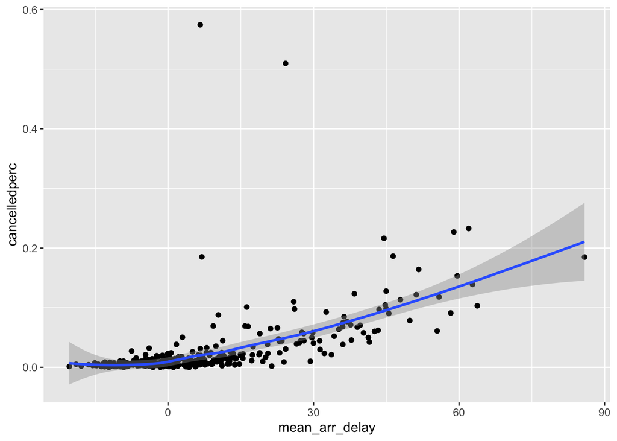

```r
# 4
flights %>%
  mutate(cancelled = 1 * is.na(arr_time)) %>%
  group_by(month,day) %>%
  summarise(cancelledperc = mean(cancelled),mean_dep_delay = mean(dep_delay,na.rm = TRUE),mean_arr_delay = mean(arr_delay,na.rm = TRUE))%>%
ggplot(aes(x = mean_arr_delay,y = cancelledperc)) +
  geom_point()+
  geom_smooth()
```

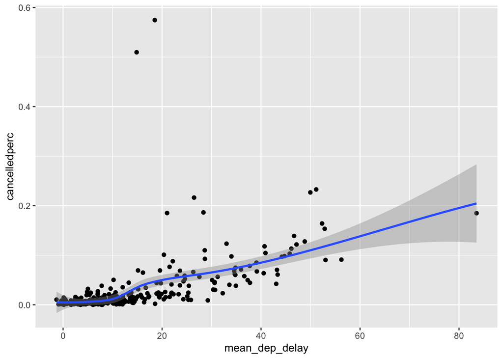

```r
flights %>%
  mutate(cancelled = 1 * is.na(arr_time)) %>%
  group_by(month,day) %>%
  summarise(cancelledperc = mean(cancelled),mean_dep_delay = mean(dep_delay,na.rm = TRUE),mean_dep_delay = mean(dep_delay,na.rm = TRUE))%>%
ggplot(aes(x = mean_dep_delay,y = cancelledperc)) +
  geom_point()+
  geom_smooth()
```

```r
# 5
not_cancelled%>%
  group_by(carrier) %>%
  summarise(mean_arr_delay = mean(arr_delay),n = n()) %>%
  filter(n>50)%>%
  arrange(desc(mean_arr_delay))
```

```
## # A tibble: 15 × 3
##    carrier mean_arr_delay     n
##    <chr>            <dbl> <int>
##  1 F9              21.9     681
##  2 FL              20.1    3175
##  3 EV              15.8   51108
##  4 YV              15.6     544
##  5 MQ              10.8   25037
##  6 WN               9.65  12044
##  7 B6               9.46  54049
##  8 9E               7.38  17294
##  9 UA               3.56  57782
## 10 US               2.13  19831
## 11 VX               1.76   5116
## 12 DL               1.64  47658
## 13 AA               0.364 31947
## 14 HA              -6.92    342
## 15 AS              -9.93    709
```

```r
  not_cancelled%>%
  group_by(dest) %>%
  summarise(mean_arr_delay = mean(arr_delay),n = n()) %>%
  filter(n>50)%>%
  arrange(desc(mean_arr_delay))
```

```
## # A tibble: 94 × 3
##    dest  mean_arr_delay     n
##    <chr>          <dbl> <int>
##  1 CAE             41.8   106
##  2 TUL             33.7   294
##  3 OKC             30.6   315
##  4 TYS             24.1   578
##  5 MSN             20.2   556
##  6 RIC             20.1  2346
##  7 CAK             19.7   842
##  8 DSM             19.0   523
##  9 GRR             18.2   728
## 10 BHM             16.9   269
## # … with 84 more rows
```

```r
# makes a df where each destination airport has an average delay value
rport_avg_delay <- not_cancelled%>%
  group_by(dest) %>%
  summarise(mean_arr_delay = mean(arr_delay),n = n())
#testing stuff
rport_avg_delay$mean_arr_delay[rport_avg_delay$dest== "HNL"]
```

```
## [1] -1.365193
```

```r
rport_avg_delay %>%
  summarise(mean(mean_arr_delay))
```

```
## # A tibble: 1 × 1
##   `mean(mean_arr_delay)`
##                    <dbl>
## 1                   8.73
```

```r
not_cancelled%>%
  group_by(dest) %>%
  summarise(mean_arr_delay = mean(arr_delay),n = n())
```

```
## # A tibble: 104 × 3
##    dest  mean_arr_delay     n
##    <chr>          <dbl> <int>
##  1 ABQ             4.38   254
##  2 ACK             4.85   264
##  3 ALB            14.4    418
##  4 ANC            -2.5      8
##  5 ATL            11.3  16837
##  6 AUS             6.02  2411
##  7 AVL             8.00   261
##  8 BDL             7.05   412
##  9 BGR             8.03   358
## 10 BHM            16.9    269
## # … with 94 more rows
```

```r
#now computing in relation to destination
not_cancelled%>%
  mutate(avg_delay =mean(arr_delay)) %>% # this line does not work.
  group_by(carrier) %>%
  select(avg_delay,dest)
```

```
## # A tibble: 327,346 × 3
## # Groups:   carrier [16]
##    carrier avg_delay dest
##    <chr>       <dbl> <chr>
##  1 UA           6.90 IAH
##  2 UA           6.90 IAH
##  3 AA           6.90 MIA
##  4 B6           6.90 BQN
##  5 DL           6.90 ATL
##  6 UA           6.90 ORD
##  7 B6           6.90 FLL
##  8 EV           6.90 IAD
##  9 B6           6.90 MCO
## 10 AA           6.90 ORD
## # … with 327,336 more rows
```

```r
flights %>%
  count(dest,sort = TRUE)
```

```
## # A tibble: 105 × 2
##    dest      n
##    <chr> <int>
##  1 ORD   17283
##  2 ATL   17215
##  3 LAX   16174
##  4 BOS   15508
##  5 MCO   14082
##  6 CLT   14064
##  7 SFO   13331
##  8 FLL   12055
##  9 MIA   11728
## 10 DCA    9705
## # … with 95 more rows
```

arr_time is the most important column to determine if the flight was cancelled. There seems to be a positive correlation between cancelled flights and arr delay, but a stronger(and kind of weirder correlation) between dep delay and cancelled flights. Also, the day where they cancelled 50% of the flights is impressive. How do you do that? I think that disentangling the airplane from the airport is pretty hard, as if one airport gets dominated by a bad carrier, we cant really fault the airport. The only solution I could find was just to take the average of the airport and multiply it by the flight The sort argument orders the counts by maximum. How to sort in descending order is not in the documentation.

```r
not_cancelled %>%
  mutate(late = arr_delay>0) %>%
   group_by(tailnum) %>%
  summarize(on_time = mean(late))%>%
  arrange(desc(on_time)) %>%
  select(on_time)
```

```
## # A tibble: 4,037 × 1
##    on_time
##      <dbl>
##  1       1
##  2       1
##  3       1
##  4       1
##  5       1
##  6       1
##  7       1
##  8       1
##  9       1
## 10       1
## # … with 4,027 more rows
```

```r
#| label.5.7.1.3
```

I dont really know what 1. means. How shoud it “change”